# Evaluation of the Effects of Practices and School Type on Exam Scores

> The GCSE exam scores dataset from the mlmRev package was used. The objective of this assignment was to evaluate the efects of the different variables in the dataset on an exam score.

# 1. We load the database and examine the variables included.

```r
library(mlmRev)
data(Gcsemv)

options(scipen=20)
head(Gcsemv)
```

```
##   school student gender written course
## 1  20920      16      M      23     NA
## 2  20920      25      F      NA   71.2
## 3  20920      27      F      39   76.8
## 4  20920      31      F      36   87.9
## 5  20920      42      M      16   44.4
## 6  20920      62      F      36     NA
```

# 2. Run the full sequence of models necessary to perform a comprehensive evaluation of the effects of the variable exercise in the course (course) on the written exam scores (written). Report and interpret the results for each of the models.

## Inconditional Model

```r
library(lme4)
library(lmerTest)
Written_un<-lmer(written ~(1|school), Gcsemv, REML = FALSE)
summary(Written_un)
```

```
## Linear mixed model fit by maximum likelihood . t-tests use Satterthwaite's
##   method [lmerModLmerTest]
## Formula: written ~ (1 | school)
##    Data: Gcsemv
##
##      AIC      BIC   logLik deviance df.resid
##  13226.6  13242.9  -6610.3  13220.6     1700
##
## Scaled residuals:
##     Min      1Q  Median      3Q     Max
## -3.0049 -0.6726 -0.0439  0.6466  3.7517
##
## Random effects:
##  Groups   Name        Variance Std.Dev.
##  school   (Intercept)  48.77    6.983
##  Residual             126.07   11.228
## Number of obs: 1703, groups:  school, 73
##
## Fixed effects:
##             Estimate Std. Error      df t value            Pr(>|t|)
## (Intercept)  47.5973     0.8935 67.5980   53.27 <0.0000000000000002 ***
## ---
## Signif. codes:  0 '***' 0.001 '**' 0.01 '*' 0.05 '.' 0.1 ' ' 1
```

```r
library(sjPlot)
tab_model(Written_un)
```

|  | written |  |  |
| --- | --- | --- | --- |
| Predictors | Estimates | CI | p |
| (Intercept) | 47.60 | 45.84 – 49.35 | **<0.001** |
| Random Effects |  |  |  |
| σ<sup>2</sup> | 126.07 |  |  |
| τ<sub>00</sub> <sub>school</sub> | 48.77 |  |  |
| ICC | 0.28 |  |  |
| N <sub>school</sub> | 73 |  |  |
| Observations | 1703 |  |  |
| Marginal R<sup>2</sup> / Conditional R<sup>2</sup> | 0.000 / 0.279 |  |  |

> The estimated average score for students from all schools on the written exam is 47.60. Y00 = 47.60, SE = 0.89, 95% CI [45.85, 49.35], t(68) = 53.27, p < .001.

### Centering of predictors for HREM (Hybrid Random Effects Models):

```r
library(tidyverse)
Gcsemv <- Gcsemv %>%
  group_by(school) %>%
  mutate(course_bw = mean(course, na.rm = TRUE)) %>%
  ungroup() %>%
  mutate(course_wt = course - course_bw,
         c_course_bw = course_bw - mean(course_bw, na.rm = TRUE))
```

> Two new variables are created. On the one hand, course_wt measures how much an individual’s course score deviates from their school’s average (course_bw). On the other hand, c_course_bw represents how much each school’s average score (course_bw) deviates from the overall average across all schools. This allows for the analysis of both within-school and between-school variations in course performance.

## Fixed Model

```r
Written_hrem_fixed<-lmer(written ~ course_wt + c_course_bw + (1|school), Gcsemv, REML = FALSE)
summary(Written_hrem_fixed)
```

```
## Linear mixed model fit by maximum likelihood . t-tests use Satterthwaite's
##   method [lmerModLmerTest]
## Formula: written ~ course_wt + c_course_bw + (1 | school)
##    Data: Gcsemv
##
##      AIC      BIC   logLik deviance df.resid
##  11507.0  11533.6  -5748.5  11497.0     1518
##
## Scaled residuals:
##     Min      1Q  Median      3Q     Max
## -3.6551 -0.6781 -0.0281  0.6677  3.5599
##
## Random effects:
##  Groups   Name        Variance Std.Dev.
##  school   (Intercept)  41.57    6.447
##  Residual             100.94   10.047
## Number of obs: 1523, groups:  school, 73
##
## Fixed effects:
##               Estimate Std. Error         df t value             Pr(>|t|)
## (Intercept)   47.58649    0.83082   67.73852  57.276 < 0.0000000000000002 ***
## course_wt      0.35938    0.01888 1449.82537  19.038 < 0.0000000000000002 ***
## c_course_bw    0.34119    0.08729   71.91703   3.909             0.000208 ***
## ---
## Signif. codes:  0 '***' 0.001 '**' 0.01 '*' 0.05 '.' 0.1 ' ' 1
##
## Correlation of Fixed Effects:
##             (Intr) crs_wt
## course_wt   -0.001
## c_course_bw -0.046  0.002
```

```r
tab_model(Written_hrem_fixed)
```

|  | written |  |  |
| --- | --- | --- | --- |
| Predictors | Estimates | CI | p |
| (Intercept) | 47.59 | 45.96 – 49.22 | **<0.001** |
| course wt | 0.36 | 0.32 – 0.40 | **<0.001** |
| c course bw | 0.34 | 0.17 – 0.51 | **<0.001** |
| Random Effects |  |  |  |
| σ<sup>2</sup> | 100.94 |  |  |
| τ<sub>00</sub> <sub>school</sub> | 41.57 |  |  |
| ICC | 0.29 |  |  |
| N <sub>school</sub> | 73 |  |  |
| Observations | 1523 |  |  |
| Marginal R<sup>2</sup> / Conditional R<sup>2</sup> | 0.192 / 0.428 |  |  |

> The estimated average score on the written exam for students attending schools with average course levels is 47.59 points. Y₀₀ = 47.59, SE = 0.83, 95% CI [45.96, 49.21], t(68) = 57.28, p < .001.  
> Significant effects were observed both within-school and between-school regarding the course on the written exam scores.  
> A significant effect of course variations on the written exam scores was observed. A one-unit deviation from the school’s average course level is estimated to result in an increase of 0.36 units in the written exam score. Y₁₀ = 0.36, SE = 0.02, 95% CI [0.32, 0.40], t(1449) = 19.04, p < .001.  
> A significant effect of the overall course score of the schools on students’ written exam scores was also observed. For each unit increase in school course score, a 0.34 unit increase in the written exam score is estimated. Y₀₁ = 0.34, SE = 0.09, 95% CI [0.17, 0.51], t(72) = 3.91, p < .001.

## Random Model

```r
Written_hrem_random<-lmer(written ~ course_wt + c_course_bw + (course_wt|school), Gcsemv, REML = FALSE)
summary(Written_hrem_random)
```

```
## Linear mixed model fit by maximum likelihood . t-tests use Satterthwaite's
##   method [lmerModLmerTest]
## Formula: written ~ course_wt + c_course_bw + (course_wt | school)
##    Data: Gcsemv
##
##      AIC      BIC   logLik deviance df.resid
##  11483.0  11520.3  -5734.5  11469.0     1516
##
## Scaled residuals:
##     Min      1Q  Median      3Q     Max
## -3.7426 -0.6722 -0.0206  0.6709  3.7074
##
## Random effects:
##  Groups   Name        Variance Std.Dev. Corr
##  school   (Intercept) 41.54795 6.4458
##           course_wt    0.02138 0.1462   -0.43
##  Residual             96.82978 9.8402
## Number of obs: 1523, groups:  school, 73
##
## Fixed effects:
##             Estimate Std. Error       df t value             Pr(>|t|)
## (Intercept) 47.61476    0.82814 67.63532   57.50 < 0.0000000000000002 ***
## course_wt    0.34653    0.02851 45.68445   12.15 0.000000000000000647 ***
## c_course_bw  0.36146    0.08426 69.39483    4.29 0.000056800070587719 ***
## ---
## Signif. codes:  0 '***' 0.001 '**' 0.01 '*' 0.05 '.' 0.1 ' ' 1
##
## Correlation of Fixed Effects:
##             (Intr) crs_wt
## course_wt   -0.258
## c_course_bw -0.044  0.023
```

```r
tab_model(Written_hrem_random)
```

|  | written |  |  |
| --- | --- | --- | --- |
| Predictors | Estimates | CI | p |
| (Intercept) | 47.61 | 45.99 – 49.24 | **<0.001** |
| course wt | 0.35 | 0.29 – 0.40 | **<0.001** |
| c course bw | 0.36 | 0.20 – 0.53 | **<0.001** |
| Random Effects |  |  |  |
| σ<sup>2</sup> | 96.83 |  |  |
| τ<sub>00</sub> <sub>school</sub> | 41.55 |  |  |
| τ<sub>11</sub> <sub>school.course_wt</sub> | 0.02 |  |  |
| ρ<sub>01</sub> <sub>school</sub> | -0.43 |  |  |
| ICC | 0.32 |  |  |
| N <sub>school</sub> | 73 |  |  |
| Observations | 1523 |  |  |
| Marginal R<sup>2</sup> / Conditional R<sup>2</sup> | 0.190 / 0.449 |  |  |

```r
anova(Written_hrem_fixed, Written_hrem_random)
```

```
## Data: Gcsemv
## Models:
## Written_hrem_fixed: written ~ course_wt + c_course_bw + (1 | school)
## Written_hrem_random: written ~ course_wt + c_course_bw + (course_wt | school)
##                     npar   AIC   BIC  logLik deviance  Chisq Df   Pr(>Chisq)
## Written_hrem_fixed     5 11507 11534 -5748.5    11497
## Written_hrem_random    7 11483 11520 -5734.5    11469 27.944  2 0.0000008551
##
## Written_hrem_fixed
## Written_hrem_random ***
## ---
## Signif. codes:  0 '***' 0.001 '**' 0.01 '*' 0.05 '.' 0.1 ' ' 1
```

> Incorporating the within predictor as random improves the model fit. X²(2) = 27.94, p < .001.  
> The estimated average score on the written exam for students attending schools with average course levels is 47.61 points. Y₀₀ = 47.61, SE = 0.83, 95% CI [45.99, 49.24], t(68) = 57.50, p < .001.  
> Significant effects were observed both within-school and between-school regarding the course on the written exam scores.  
> A significant effect of course variations on the written exam scores was observed. A one-unit deviation from the school’s average course level is estimated to result in an increase of 0.35 units in the written exam score. Y₁₀ = 0.35, SE = 0.03, 95% CI [0.29, 0.40], t(45) = 12.15, p < .001.  
> A significant effect of the overall course score of the schools on students’ written exam scores was also observed. For each unit increase in course score, a 0.36 unit increase in the written exam score is estimated. Y₀₁ = 0.36, SE = 0.08, 95% CI [0.20, 0.53], t(69) = 4.29, p < .001.

# 3. What conclusions could we draw regarding the effects of exercise on the exam scores?

> As observed in the model, course levels seem to have an effect on the written exam scores both within schools and between them. Within the same school, students with scores higher than the school’s average in the course variable appear to have better written exam scores. Similarly, students attending schools with scores higher than the overall average across all schools in the course also seem to have higher written exam scores.

# 4. Include a cross-level interaction effect between the intra- and inter-school components of exercise to explain the written exam scores. How are the results interpreted? Create a graph that illustrates this effect.

```r
Written_hrem_rand_int<-lmer(written ~ course_wt * c_course_bw + (course_wt|school), Gcsemv, REML = FALSE)
summary(Written_hrem_rand_int)
```

```
## Linear mixed model fit by maximum likelihood . t-tests use Satterthwaite's
##   method [lmerModLmerTest]
## Formula: written ~ course_wt * c_course_bw + (course_wt | school)
##    Data: Gcsemv
##
##      AIC      BIC   logLik deviance df.resid
##  11484.1  11526.8  -5734.1  11468.1     1515
##
## Scaled residuals:
##     Min      1Q  Median      3Q     Max
## -3.7599 -0.6768 -0.0214  0.6619  3.7099
##
## Random effects:
##  Groups   Name        Variance Std.Dev. Corr
##  school   (Intercept) 46.82592 6.8429
##           course_wt    0.02177 0.1475   -0.44
##  Residual             96.25720 9.8111
## Number of obs: 1523, groups:  school, 73
##
## Fixed effects:
##                        Estimate Std. Error        df t value
## (Intercept)           47.645616   0.871354 58.684588  54.680
## course_wt              0.347754   0.028615 48.481920  12.153
## c_course_bw            0.337743   0.091384 62.010226   3.696
## course_wt:c_course_bw  0.003527   0.003163 49.335086   1.115
##                                   Pr(>|t|)
## (Intercept)           < 0.0000000000000002 ***
## course_wt             0.000000000000000251 ***
## c_course_bw                       0.000466 ***
## course_wt:c_course_bw             0.270157
## ---
## Signif. codes:  0 '***' 0.001 '**' 0.01 '*' 0.05 '.' 0.1 ' ' 1
##
## Correlation of Fixed Effects:
##             (Intr) crs_wt c_crs_
## course_wt   -0.261
## c_course_bw -0.044  0.012
## crs_wt:c_c_  0.012  0.039 -0.251
## optimizer (nloptwrap) convergence code: 0 (OK)
## Model failed to converge with max|grad| = 0.723336 (tol = 0.002, component 1)
```

> Since the model with random effects interaction does not converge, the interaction will be analyzed in the fixed-effects model.

```r
Written_hrem_fixed_int<-lmer(written ~ course_wt * c_course_bw + (1|school), Gcsemv, REML = FALSE)
summary(Written_hrem_fixed_int)
```

```
## Linear mixed model fit by maximum likelihood . t-tests use Satterthwaite's
##   method [lmerModLmerTest]
## Formula: written ~ course_wt * c_course_bw + (1 | school)
##    Data: Gcsemv
##
##      AIC      BIC   logLik deviance df.resid
##  11508.8  11540.8  -5748.4  11496.8     1517
##
## Scaled residuals:
##     Min      1Q  Median      3Q     Max
## -3.6592 -0.6771 -0.0259  0.6632  3.5657
##
## Random effects:
##  Groups   Name        Variance Std.Dev.
##  school   (Intercept)  41.56    6.447
##  Residual             100.93   10.047
## Number of obs: 1523, groups:  school, 73
##
## Fixed effects:
##                           Estimate   Std. Error           df t value
## (Intercept)             47.5871401    0.8307500   67.7352796  57.282
## course_wt                0.3605968    0.0192373 1449.6460917  18.745
## c_course_bw              0.3409910    0.0872844   71.9186517   3.907
## course_wt:c_course_bw    0.0006801    0.0020679 1449.6769411   0.329
##                                   Pr(>|t|)
## (Intercept)           < 0.0000000000000002 ***
## course_wt             < 0.0000000000000002 ***
## c_course_bw                       0.000209 ***
## course_wt:c_course_bw             0.742307
## ---
## Signif. codes:  0 '***' 0.001 '**' 0.01 '*' 0.05 '.' 0.1 ' ' 1
##
## Correlation of Fixed Effects:
##             (Intr) crs_wt c_crs_
## course_wt    0.000
## c_course_bw -0.046  0.001
## crs_wt:c_c_  0.002  0.193 -0.007
```

```r
tab_model(Written_hrem_fixed_int)
```

|  | written |  |  |
| --- | --- | --- | --- |
| Predictors | Estimates | CI | p |
| (Intercept) | 47.59 | 45.96 – 49.22 | **<0.001** |
| course wt | 0.36 | 0.32 – 0.40 | **<0.001** |
| c course bw | 0.34 | 0.17 – 0.51 | **<0.001** |
| course wt × c course bw | 0.00 | -0.00 – 0.00 | 0.742 |
| Random Effects |  |  |  |
| σ<sup>2</sup> | 100.93 |  |  |
| τ<sub>00</sub> <sub>school</sub> | 41.56 |  |  |
| ICC | 0.29 |  |  |
| N <sub>school</sub> | 73 |  |  |
| Observations | 1523 |  |  |
| Marginal R<sup>2</sup> / Conditional R<sup>2</sup> | 0.192 / 0.428 |  |  |

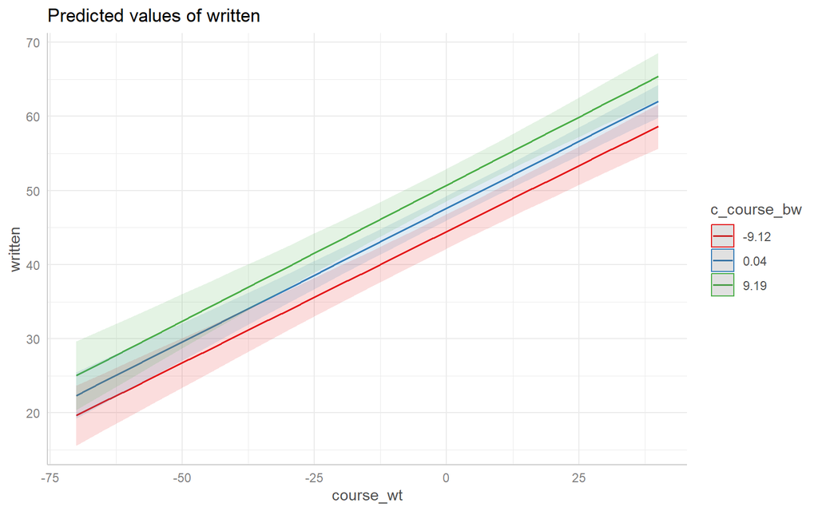

```r
library(ggeffects)
efecto_marginal <- ggpredict(Written_hrem_fixed_int, terms = c("course_wt", "c_course_bw"))
plot(efecto_marginal)
```

> No significant effect was found for the average school course levels on the effect of course variations on written exam scores. Y11 = 0.00068, SE = 0.002, 95% CI [-0, 0], t(1449) = 0.33, p = .74.  
> A significant effect of the average course levels of schools on exam scores was observed. For each unit increase in the course, an increase of 0.34 units in the exam score is estimated. Y01 = 0.34, SE = 0.09, 95% CI [0.17, 0.51], t(72) = 3.91, p < .001.  
> A significant effect of course variations on exam scores was also observed for a school with an average course level. For each unit increase in variations, an increase of 0.36 units in the exam score is estimated. Y10 = 0.36, SE = 0.02, 95% CI [0.32, 0.40], t(1449) = 18.75, p < .001.  
> Moreover, an average written exam score of 47.59 points is estimated for students attending schools with average course levels. Y00 = 47.59, SE = 0.83, 95% CI [45.96, 49.22], t(68) = 57.28, p < .001.

# Final Report

> The analysis reveals that course levels significantly impact written exam scores, both within individual schools and across schools. Students who score above their school’s average in the course tend to achieve better written exam results, and students at schools with higher-than-average course scores also perform better on the written exam. Furthermore, the effect of course levels on written exam scores is significant, with each unit increase in the course level corresponding to an estimated increase of 0.34 units in the exam score (p < .001). Additionally, variations in course scores within schools have a substantial impact on exam performance, with each unit increase in variations leading to an estimated increase of 0.36 units in the exam score (p < .001). For students attending schools with average course levels, the average written exam score is estimated at 47.59 points (p < .001). These findings highlight the importance of course performance, both within schools and across schools, in influencing written exam outcomes.